# Ancient cities and inscriptions

Alexandra Pasternakova

13/01/2021 updated February 18, 2022

In this exercise you will map the ancient equivalent of Twitter data: the ancient inscriptions. Ancient people of class, education, and means liked to advertise their achievements and life milestones as well as their sorrows via the means of texts inscribed in stone. These epigraphic monuments were often placed near inhabited areas, roads, and gathering places where they were likely to attract the largest audience. The location of these self-expressions in space and time is a reasonable indicator of changing economic prosperity of the commissioning communities. In this exercise, you will explore how these ancient inscriptions spatially correspond to the distribution of ancient cities and settlements.

# Task 1: Load ancient cities and convert to sf object

John Hanson has created a dataset of all cities in the ancient Mediterranean and made it available online. You will download this dataset and convert it into an sf object in order to compare with the inscriptions on the basis of location.

- Use `read_csv()` to load `Hanson2016_Cities_OxREP.csv` dataset from the provided URL and assign it to `cities` object

```r
cities <- as.data.frame(read_csv("http://oxrep.classics.ox.ac.uk/oxrep/docs/Hanson2016/Hanson2016_Cities_OxREP.csv"))
```

… then reproject this data to EPSG 3035

```r
# Convert the table into an sf object on the basis of X and Y columns
cities_sf <- st_as_sf(cities, coords = c("Longitude (X)", "Latitude (Y)"))

# Define the projection of Lat/Long coordinates as EPSG 4326
cities_sf4326 <- st_set_crs(cities_sf, 4326)

# Transform the projection to a 2D projection using EPSG 3035
cities_sf3035 <- st_transform(cities_sf4326, 3035)

# Verify the projection is 'projected' not 'geographic'
head(cities_sf3035)
```

```
Simple feature collection with 6 features and 10 fields
Geometry type: POINT
Dimension:     XY
Bounding box:  xmin: 5380930 ymin: 1734580 xmax: 5527223 ymax: 1817990
Projected CRS: ETRS89-extended / LAEA Europe
   Primary Key Ancient Toponym Modern Toponym Province Country
1 Hanson2016_1            Abae       Kalapodi   Achaea  Greece
2 Hanson2016_2        Acharnae       Acharnes   Achaea  Greece
3 Hanson2016_3       Acraephia      Akraifnio   Achaea  Greece
4 Hanson2016_4          Aegina         Aigina   Achaea  Greece
5 Hanson2016_5          Aegira        Aigeira   Achaea  Greece
6 Hanson2016_6          Aegium          Aigio   Achaea  Greece
  Barrington Atlas Rank Barrington Atlas Reference Start Date End Date
1                4 or 5                      55 D3       -600     NULL
2                     3                      59 B2       -600     NULL
```

[output cut: 18 more lines]

```r
st_crs(cities_sf3035)
```

```
Coordinate Reference System:
  User input: EPSG:3035
  wkt:
PROJCRS["ETRS89-extended / LAEA Europe",
    BASEGEOGCRS["ETRS89",
        DATUM["European Terrestrial Reference System 1989",
            ELLIPSOID["GRS 1980",6378137,298.257222101,
                LENGTHUNIT["metre",1]]],
        PRIMEM["Greenwich",0,
            ANGLEUNIT["degree",0.0174532925199433]],
        ID["EPSG",4258]],
    CONVERSION["Europe Equal Area 2001",
        METHOD["Lambert Azimuthal Equal Area",
            ID["EPSG",9820]],
        PARAMETER["Latitude of natural origin",52,
            ANGLEUNIT["degree",0.0174532925199433],
            ID["EPSG",8801]],
        PARAMETER["Longitude of natural origin",10,
            ANGLEUNIT["degree",0.0174532925199433],
            ID["EPSG",8802]],
        PARAMETER["False easting",4321000,
            LENGTHUNIT["metre",1],
            ID["EPSG",8806]],
        PARAMETER["False northing",3210000,
            LENGTHUNIT["metre",1],
            ID["EPSG",8807]]],
    CS[Cartesian,2],
        AXIS["northing (Y)",north,
            ORDER[1],
            LENGTHUNIT["metre",1]],
        AXIS["easting (X)",east,
            ORDER[2],
            LENGTHUNIT["metre",1]],
    USAGE[
        SCOPE["Statistical analysis."],
        AREA["Europe - European Union (EU) countries and candidates. Europe - onshore and offshore: Albania; Andorra; Austria; Belgium; Bosnia and Herzegovina; Bulgaria; Croatia; Cyprus; Czechia; Denmark; Estonia; Faroe Islands; Finland; France; Germany; Gibraltar; Greece; Hungary; Iceland; Ireland;…
        BBOX[24.6,-35.58,84.17,44.83]],
    ID["EPSG",3035]]
```

### Question:

*1. What are the measurement units of the `cities_sf3035` object?*

- The unit is meter. I can see that from st_crs(cities_sf3035) in the console output: LENGTHUNIT[“metre”…

# Task 2: Create a buffer around each city and inspect the result

As each city and inscription corresponds to a dot on the map, the best way to grab and review the inscriptions will be by creating a buffer around each city and then selecting the inscriptions that fall into the buffer as belonging to the city.

- Create a buffer around the `cities_sf3035` geometry with `st_buffer()` , setting the `dist` argument to the desired radius of 5000m.
- Plot the first ten buffers and the first ten cities on top for a quick review. Can you tell that the buffers are really 5000m?

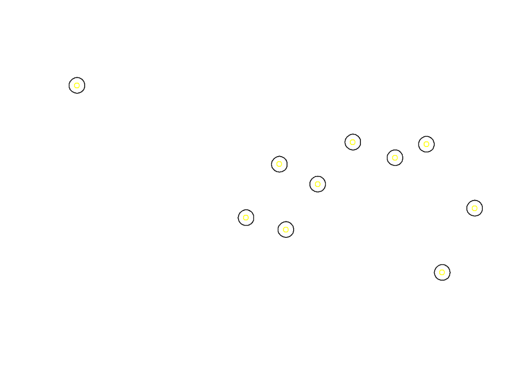

```r
# Make buffer of 5 km. Check the units of your object to correctly assign value
# to dist
cities_5km <- st_buffer(cities_sf3035, dist = 5000)

# Plot the first 10 buffers and cities to check result
plot(st_geometry(cities_sf3035)[1:10], col = "yellow")
plot(st_geometry(cities_5km)[1:10], pch = 20, cex = 0.1, add = TRUE)
```

# Task 3: Verify the city buffers are indeed 5km in radius

Well, a quick review may look ok, but you cannot be sure your buffers work well until you add them to a map with a scale. Verify that your buffers are as big as should be by plotting a sample with tmap and adding a scale.

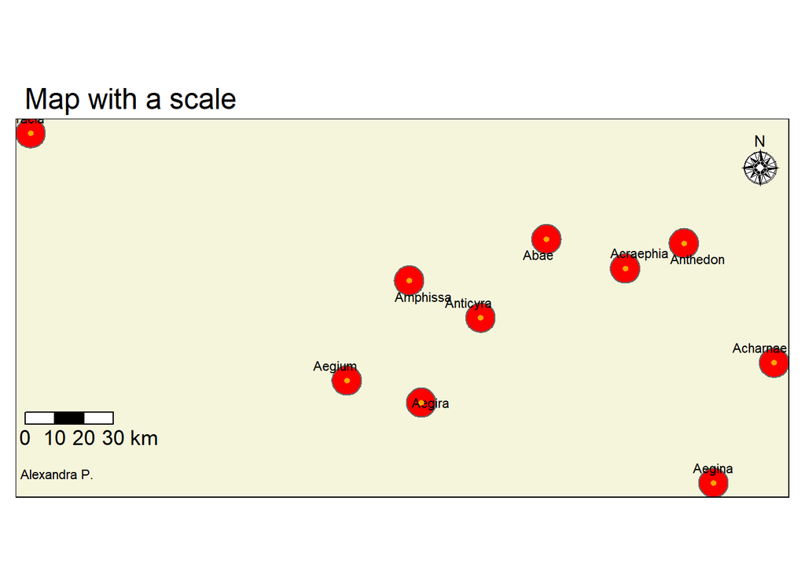

```r
# Grab the first 10 elements in the sf object and the buffer
ten_buffers <- cities_5km %>%
    slice(1:10)
ten_cities <- cities_sf3035 %>%
    slice(1:10)

# Create a quick tmap
library(tmap)
current.mode <- tmap_mode("plot")

tm_shape(ten_buffers) + tm_polygons(col = "red") + tm_shape(ten_cities) + tm_text("Ancient Toponym",
    size = 0.7, auto.placement = 5) + tm_dots(col = "orange", size = 0.1) + tm_scale_bar(breaks = c(0,
    10, 20, 30), text.size = 16, position = c("LEFT", "bottom")) + tm_compass(position = c("RIGHT",
    "top"), type = "rose", size = 2) + tm_credits(position = c("LEFT", "bottom"),
    text = "Alexandra P.") + tm_layout(main.title = "Map with a scale", bg.color = "beige",
    inner.margins = c(0, 0, 0, 0))
```

If all went well, you should see a map, where the diameter of each city buffer corresponds to the 10km notch on the scale. But, do you know where in the Mediterranean you are?

## An Alternative View

The `tmap` package allows you also an interactive view if you switch the `tmap_mode()` argument to `"view"`. Try it out and assess its (dis)advantages. Which arguments are retained and which are dropped from your `tm_shape` sequence?

```r
current.mode <- tmap_mode("view")

tm_shape(ten_buffers) + tm_polygons(col = "red") + tm_shape(ten_cities) + tm_text("Ancient Toponym",
    size = 0.7, auto.placement = 5) + tm_dots(col = "orange", size = 0.1) + tm_scale_bar(breaks = c(0,
    10, 20, 30), text.size = 16, position = c("LEFT", "bottom")) + tm_compass(position = c("RIGHT",
    "top"), type = "rose", size = 2) + tm_credits(position = c("LEFT", "bottom"),
    text = "Alexandra P.") + tm_layout(main.title = "Map with a scale", bg.color = "beige",
    inner.margins = c(0, 0, 0, 0))
```

[interactive chart not shown]

```r
# Credits not supported in view mode. Compass not supported in view mode. using
# this mode I can see the context of the map, meaning, where the cities
# actually are so it is definitely helpful for me to easily interpret the map,
# however, I can= t see the compass, credits or the scale bar which leads me to
# believe both modes are very useful when working with buffers
```

Now you should be able to see that the first ten towns and buffers are from mainland Greece. This flexibility of tmaps is very useful.

# Task 4: Download ancient inscriptions and wrangle coordinates into shape

Let’s now look at some data that spatially co-occurs with these ancient places. Below is a link to an online dataset from the Epigraphic Database of Heidelberg of ancient inscriptions from one part of the Mediterranean. These inscriptions combine private and official statements dedicated for personal reasons (commemorating a patron or a family member) or public (dedication of a major building, placement of milestone, etc.).

The json dataset is hefty with some 12 thousand inscriptions and 74 variables. Coordinates are nested in a single column and may need wrangling. Do tasks deliberately in small steps after you test on subsets lest you overwhelm your R.

- Download the linked file with `download.file()` into a directory where you can find it.
- The inscriptions dataset is in `.json` format (not to be confused with geojson!), which is becoming the dominant format for sharing data online, especially if some of the data is nested as is the case here. Use the `jsonlite::fromJSON` function in the library to load it back into R
- Next, use `as_tibble()` to convert into rectangular format.
- Inspect the dataset
- Check the column names for something that looks like spatial data, either Lat/Long, X/Y or a `coordinates` column.
  - Inspect the column(s) - are the coordinates meaningful? What CRS do they look like?
  - If their meaning is clear, are they in the format you need them to be for an easy conversion to an sf object?
- Separate the two values into `longitude` and `latitude` columns and convert values to numbers. Although this looks like a straightforward task of separating the two values into separate columns, you will see that there are non-numeric characters present that need to be cleaned up en route. (The column actually is formatted as c(123.4567,123.4577)) Make sure to keep the decimal point. Hint: check the `gsub()`, `grep()` and `str_extract()` functions to apply regular expressions.

```r
# Libraries
library(tidyverse)
library(jsonlite)
library(tidytext)

# Download the file and save as inscriptions.json (consider commenting out
# after you first run to avoid repeat downloading)
# download.file('https://sciencedata.dk/public/b6b6afdb969d378b70929e86e58ad975/EDH_subset_2021-02-15.json',
# 'C:/Users/alexp/Documents/School/Spatial
# analytics/HW/HW3/cds-spatial/Week03/inscriptions.json')

# Load it into R from wherever you put it, and convert into a tibble
list_json <- jsonlite::fromJSON("C:/Users/alexp/Documents/School/Spatial analytics/HW/HW3/cds-spatial/Week03/inscriptions.json")
inscriptions = as_tibble(list_json)

# Check the first couple lines and column names
head(inscriptions)
```

```
# A tibble: 6 x 74
  responsible_ind~ type_of_inscrip~ letter_size not_after literature work_status
  <chr>            <chr>            <chr>       <chr>     <chr>      <chr>
1 Feraudi          epitaph          3.2-2 cm    0130      AE 1983, ~ provisional
2 Feraudi          epitaph          4 cm        0200      AE 1983, ~ no image
3 Feraudi          epitaph          <NA>        0200      AE 1983, ~ no image
4 Feraudi          epitaph          9 cm        -0051     AE 1983, ~ checked wi~
5 Feraudi          epitaph          4-2 cm      0200      AE 1983, ~ provisional
6 Gräf             epitaph          4.2-2.5 cm  0200      AE 1983, ~ checked wi~
# ... with 68 more variables: height <chr>, diplomatic_text <chr>,
#   people <list>, depth <chr>, material <chr>, type_of_monument <chr>,
#   province_label <chr>, width <chr>, transcription <chr>, country <chr>,
#   uri <chr>, findspot_ancient <chr>, last_update <chr>, modern_region <chr>,
#   findspot_modern <chr>, language <chr>, id <chr>, edh_geography_uri <chr>,
#   commentary <chr>, trismegistos_uri <chr>, not_before <chr>,
#   external_image_uris <list>, fotos <list>, coordinates <list>, ...
```

```r
colnames(inscriptions)
```

```
 [1] "responsible_individual"           "type_of_inscription"
 [3] "letter_size"                      "not_after"
 [5] "literature"                       "work_status"
 [7] "height"                           "diplomatic_text"
 [9] "people"                           "depth"
[11] "material"                         "type_of_monument"
[13] "province_label"                   "width"
[15] "transcription"                    "country"
[17] "uri"                              "findspot_ancient"
[19] "last_update"                      "modern_region"
[21] "findspot_modern"                  "language"
[23] "id"                               "edh_geography_uri"
[25] "commentary"                       "trismegistos_uri"
[27] "not_before"                       "external_image_uris"
[29] "fotos"                            "coordinates"
```

[output cut: 22 more lines]

```r
head(unlist(inscriptions$coordinates))
```

```
14.0551 40.8472 12.4823 41.8955 12.4823 41.8955
```

```r
inscriptions$coordinates[[1]][2]
```

```
[1] 40.8472
```

```r
# Wrangle the coordinates into a 2-column format - practice on a small dataset
i_sm <- inscriptions %>%
    slice(1:100) %>%
    separate(col = coordinates, into = c("longitude", "latitude"), sep = ",") %>%
    mutate(latitude = as.numeric(gsub(")", "", gsub(" ", "", latitude))), longitude = as.numeric(gsub("c",
        "", gsub("\\(", "", longitude))))  #I did nested gsub()

# Apply the pipeline to the whole dataset, once happy with the result
i <- inscriptions %>%
    separate(col = coordinates, into = c("longitude", "latitude"), sep = ",") %>%
    mutate(latitude = as.numeric(gsub(")", "", gsub(" ", "", latitude))), longitude = as.numeric(gsub("c",
        "", gsub("\\(", "", longitude))))


# Check the result of the subset, does the location look reasonable?
leaflet(options = leafletOptions(preferCanvas = TRUE)) %>%
    addTiles() %>%
    addMarkers(lng = i_sm$longitude, lat = i_sm$latitude)
```

[interactive chart not shown]

```r
# my RStudio froze twice so I checked the small dataset instead, it really did
# not like the amount of data
```

Oooof. That was some serious wrangling!

### Question:

*2. Which part of the world are the inscriptions from?*

- most of them were from Italy and few were outside